# Simulation in R

Tong Wang

August 2017

## Overview

- Monte Carlo Simulation: to simulate the outcomes of a probablistic/stochastic model
  - Specify the model: variables, their distributions, and their relationship
  - Generate a number of realizations for each variable
  - Evaluate the model output based on the variable realizations

## Simulation of Distributions

### Random sampling

- Equally likely, without replacement

```r
letters  # a built-in vector of English letters
```

```
##  [1] "a" "b" "c" "d" "e" "f" "g" "h" "i" "j" "k" "l" "m" "n" "o" "p" "q"
## [18] "r" "s" "t" "u" "v" "w" "x" "y" "z"
```

```r
sample(x=letters, size=5)  # sample 5 letters randomly
```

```
## [1] "j" "a" "e" "o" "r"
```

```r
sample(x=letters, size=5)  # sample another 5 letters, which is independent of the previous sample
```

```
## [1] "s" "b" "f" "y" "o"
```

- Equally likely, with replacement

```r
outcomes <- c("head", "tail")
sample(x=outcomes, size=6, replace=TRUE)  # flip a coin 6 times
```

```
## [1] "tail" "head" "head" "tail" "head" "tail"
```

- With specified probabilities and replacement

```r
sample(x=outcomes, size=6, replace=TRUE, prob=c(0.3, 0.7))
```

```
## [1] "tail" "head" "tail" "head" "tail" "tail"
```

### Uniform Distribution

- Sample 10 data points from Uniform(2, 4)

```r
runif(n=10, min=2, max=4)  # type ?runif for details
```

```
##  [1] 3.022703 3.870937 2.805358 2.901883 3.335511 3.423613 2.033797
##  [8] 3.404070 3.092681 3.623638
```

### Poisson Distribution

- Sample 200 data points from Poisson(6)

```r
x.pois <- rpois(n=200, lambda=6)  # type ?rpois for details
head(x.pois)
```

```
## [1]  5  6  5  4 10  5
```

- Check the sample statistics

```r
mean(x.pois)  # mean
```

```
## [1] 5.995
```

```r
sd(x.pois)  # standard deviation
```

```
## [1] 2.58814
```

```r
table(x.pois)  # frequency table
```

```
## x.pois
##  1  2  3  4  5  6  7  8  9 10 11 12 13
##  3 12 21 29 22 33 28 20 11  8  7  5  1
```

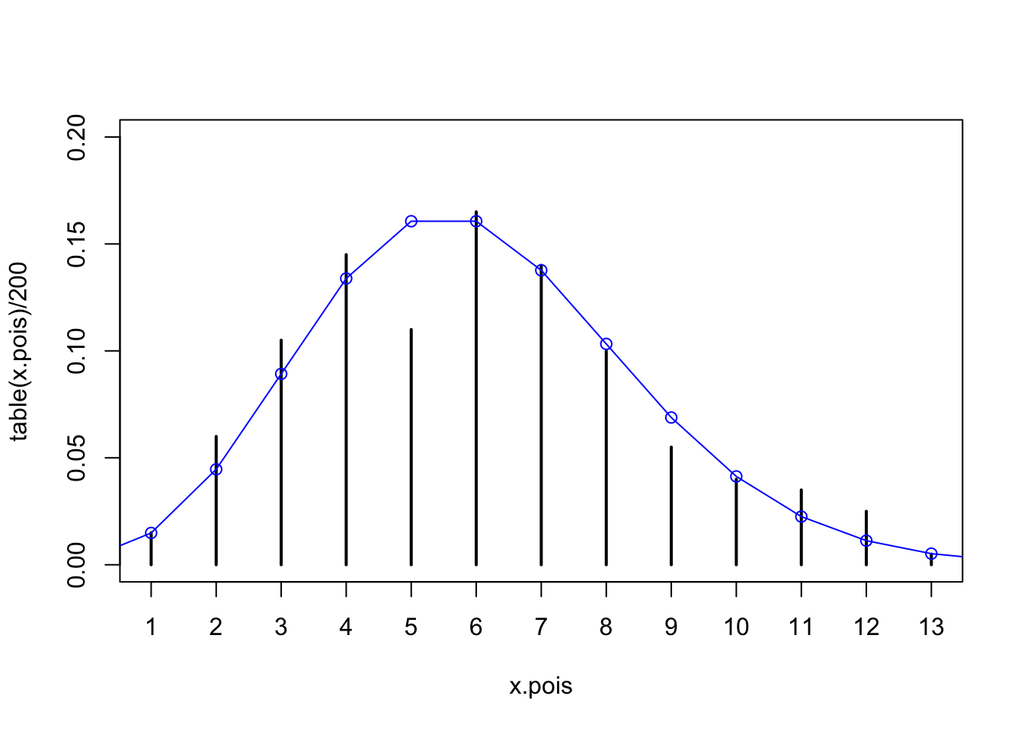

```r
plot(table(x.pois) / 200, ylim=c(0, 0.2))  # plot sample distribution
lines(0:15, dpois(0:15, lambda=6), col="blue")  # overlay of the theoretical distribution
points(0:15, dpois(0:15, lambda=6), col="blue")
```

### Binomial Distribution

- Sample 200 data points from Binomial(10, 0.7)

```r
x.binom <- rbinom(n=200, size=10, p=0.7)  # type ?rbinom for details
head(x.binom)
```

```
## [1] 5 6 7 6 8 6
```

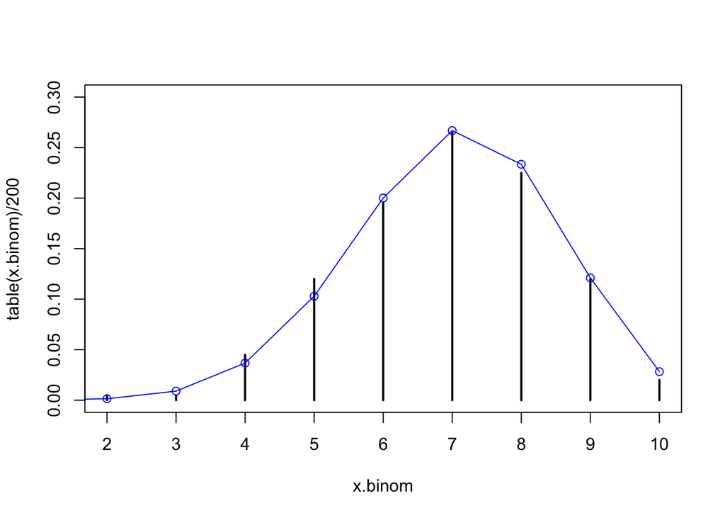

```r
plot(table(x.binom) / 200, ylim=c(0, 0.3))  # plot sample distribution
lines(0:10, dbinom(0:10, size=10, p=0.7), col="blue")  # overlay of the theoretical distribution
points(0:10, dbinom(0:10, size=10, p=0.7), col="blue")
```

### Normal Distribution

- Sample 1000 points from a standard normal distribution $N(0, 1)$

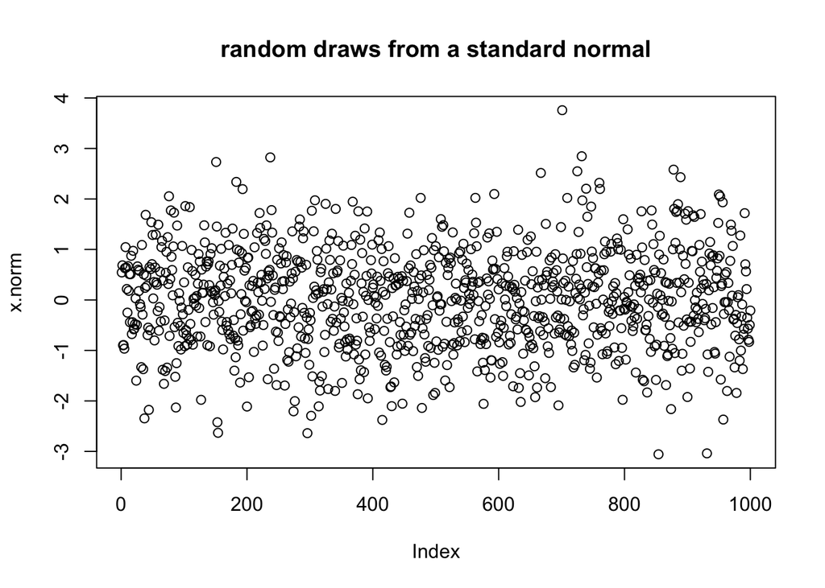

```r
x.norm <- rnorm(n=1000, mean=0, sd=1)  # type ?rnorm for details
plot(x.norm, main='random draws from a standard normal')
```

- Check the sample statistics

```r
mean(x.norm)
```

```
## [1] 0.003297065
```

```r
sd(x.norm)
```

```
## [1] 0.9733032
```

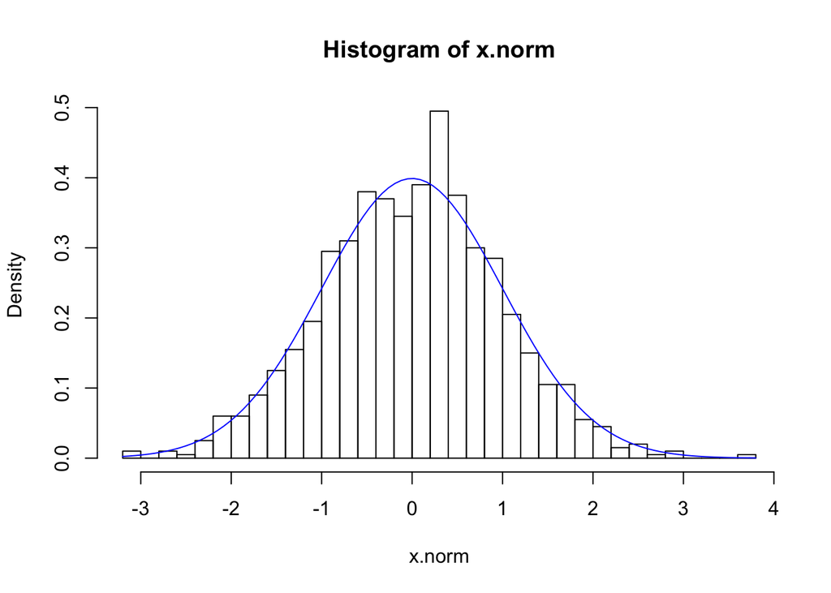

```r
hist(x.norm, probability=TRUE, breaks=30)  # plot sample distribution
curve(dnorm(x, mean=0, sd=1), add=TRUE, col="blue")  # overlay of the theoretical distribution
```

### Multivariate Normal distribution

- Sample 2000 points from a bivariate normal distribution with mean=(1, 2) and covariance matrix (9, 3; 3, 4)

```r
library("mvtnorm")  # multivariate normal distribution in package "mvtnorm"
x.mvnorm <- rmvnorm(n=2000, mean=c(1, 2), sigma=matrix(c(9, 3, 3, 4), nrow=2, ncol=2))  # type ?rmvnorm for details
head(x.mvnorm)
```

```
##            [,1]        [,2]
## [1,]  0.6961324  1.04360739
## [2,] -0.4493632  1.52796198
## [3,]  1.4011567  1.13427196
## [4,] -0.2981527  3.44655288
## [5,]  1.3229619  0.24736831
## [6,]  1.1218468 -0.05981789
```

- Check the sample statistics

```r
colMeans(x.mvnorm)  # column means
```

```
## [1] 1.013899 2.009069
```

```r
cov(x.mvnorm)  # covariance matrix
```

```
##          [,1]     [,2]
## [1,] 9.226789 2.932817
## [2,] 2.932817 3.880699
```

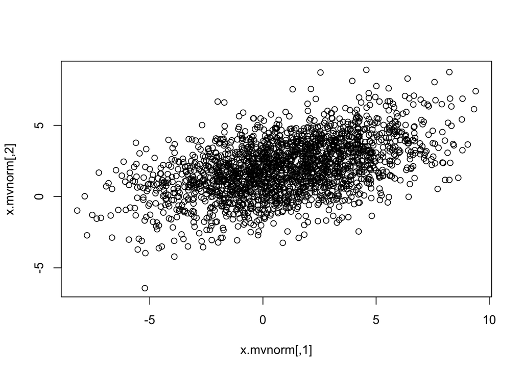

```r
plot(x.mvnorm)  # scatter plot of (x1, x2)
```

- We can also plot the density in 3D

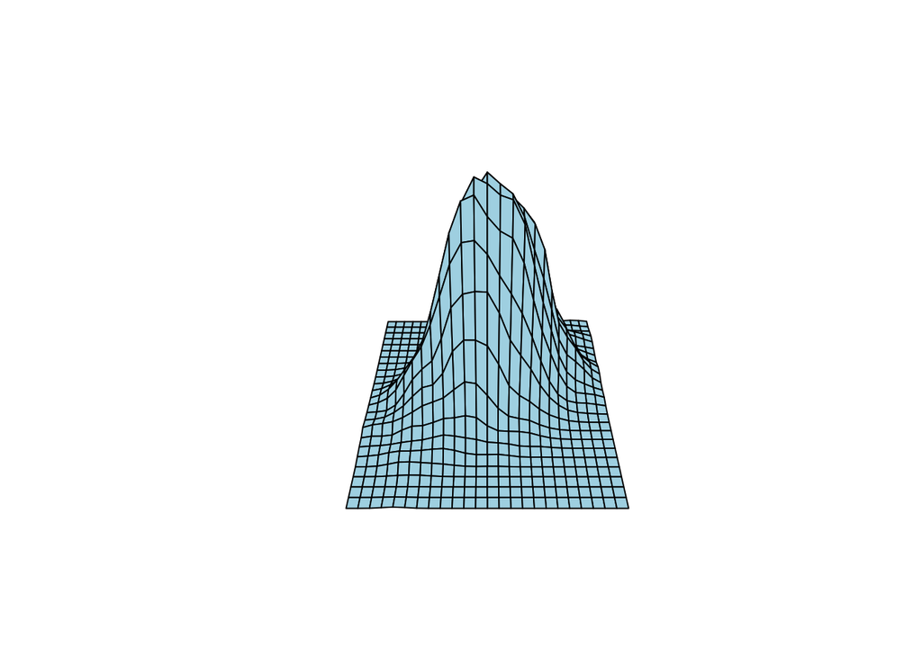

```r
library("MASS")
den3d <- kde2d(x.mvnorm[, 1], x.mvnorm[, 2])  # summarize the sample density
persp(den3d, col="lightblue", box=FALSE, theta=0, phi=40)  # 3d plot
```

- and contour plot

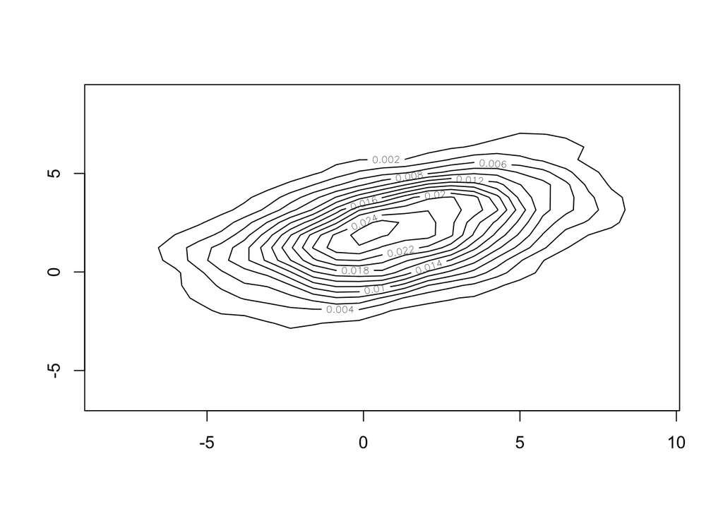

```r
contour(den3d)  # contour plot
```

## Simulation of a Model

### A Linear Model

- Specify the model and parameters in linear model $y = \beta_0 + \beta_1 * x + \epsilon$, where $\epsilon \sim N(0, \sigma^2)$

```r
beta0 <- 0  # intercept
beta1 <- 2  # slope
sigma <- 30  # epsilon ~ N(0, sigma^2)
```

- Make some random $x$ (n=100) in the interval [0, 100]

```r
x <- runif(n=100, min=0, max=100)
```

- Simulate $\epsilon$ (n=100)

```r
epsilon <- rnorm(n=100, mean=0, sd=sigma)
```

- Evaluate $y$

```r
y <- beta0 + beta1*x + epsilon
```

- Check what we have generated

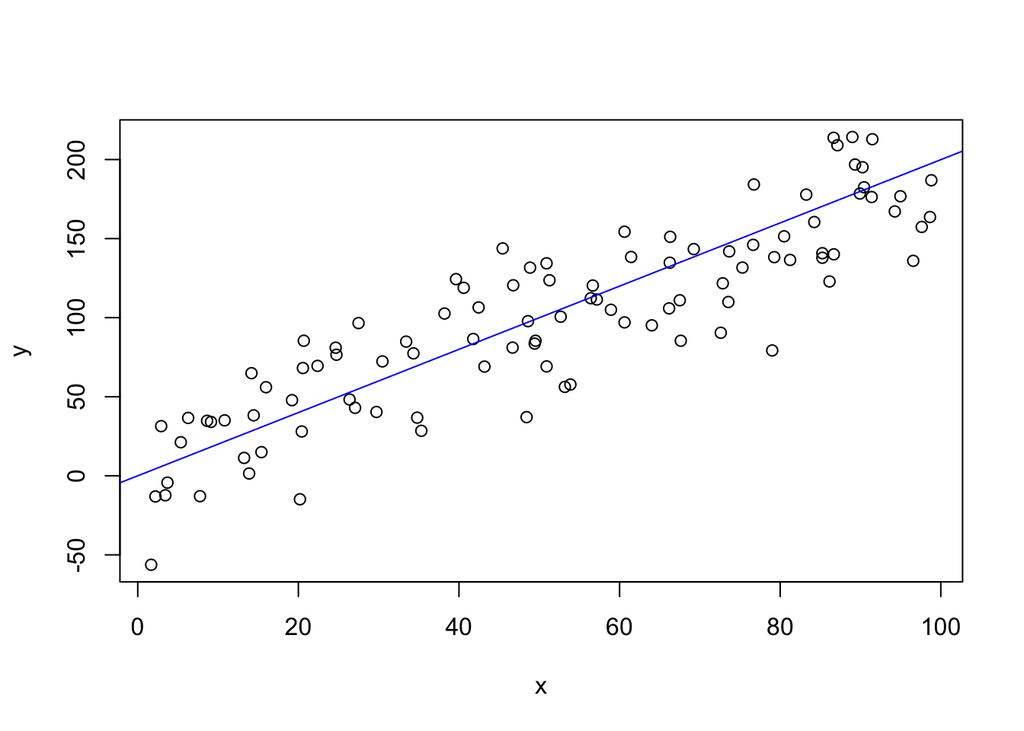

```r
plot(x, y)  # sample data
abline(a=beta0, b=beta1, col="blue")  # the TRUE data generating model
```

- Linear regression with x and y

```r
lr <- lm(y ~ x)
summary(lr)
```

```
##
## Call:
## lm(formula = y ~ x)
##
## Residuals:
##     Min      1Q  Median      3Q     Max
## -69.276 -19.273   2.629  21.957  55.636
##
## Coefficients:
##             Estimate Std. Error t value Pr(>|t|)
## (Intercept)  6.42824    5.81192   1.106    0.271
## x            1.79859    0.09813  18.329   <2e-16 ***
## ---
## Signif. codes:  0 '***' 0.001 '**' 0.01 '*' 0.05 '.' 0.1 ' ' 1
##
## Residual standard error: 28.52 on 98 degrees of freedom
## Multiple R-squared:  0.7742, Adjusted R-squared:  0.7719
## F-statistic:   336 on 1 and 98 DF,  p-value: < 2.2e-16
```

### A Classification Data

Suppose there are two groups of points, labelled in *red* and *blue*, and they have attributes $(x_1, x_2)$. The red group’s attributes centers around $x_1=2, x_2=0$, following a standard bi-variate normal distribution, whereas the blue group also follows a standard bi-variate normal distribution centering around $x_1=0, x_2=2$.

- Specify the parameters

```r
red.center <- c(2, 0)
blue.center <- c(0, 2)
cov.mat <- matrix(c(1, 0, 0, 1), nrow=2, ncol=2)
```

- Simulate 100 red points

```r
reds <- rmvnorm(n=100, mean=red.center, sigma=cov.mat)
head(reds)
```

```
##          [,1]        [,2]
## [1,] 1.018491  0.52808036
## [2,] 1.478663 -0.98965952
## [3,] 1.565748  2.23806958
## [4,] 2.722597 -0.91123563
## [5,] 2.043154 -0.01249022
## [6,] 2.100162  0.04227103
```

- Simulate 100 blue points

```r
blues <- rmvnorm(n=100, mean=blue.center, sigma=cov.mat)
head(blues)
```

```
##             [,1]     [,2]
## [1,] -1.69118881 2.168309
## [2,]  1.65727366 2.639887
## [3,]  0.47724533 1.348818
## [4,] -0.09130823 2.812639
## [5,]  1.40450125 2.204473
## [6,]  1.91320835 2.887044
```

- Plot the points

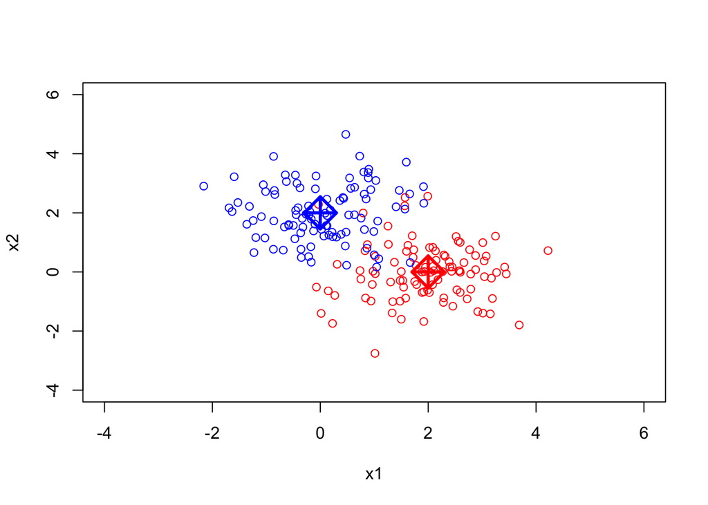

```r
plot(x=c(-4, 6), y=c(-4, 6), type="n", xlab="x1", ylab="x2")  # lay down the canvas of proper size
points(reds, col="red")  # plot the "red" points
points(blues, col="blue")  # plot the "blue" points
points(red.center[1], red.center[2], col="red", pch=9, cex=3, lwd=3)  # center for "red"
points(blue.center[1], blue.center[2], col="blue", pch=9, cex=3, lwd=3)  # center for "blue"
```

## Seed for reproducible random numbers

- Random number generation suffers from reproducibility—everytime it is run, the outcomes are different
- This can be fixed by set the *seed* of the random number generator
- Seed can be any positive integers

```r
set.seed(5678)
rnorm(n=5)
```

```
## [1] -0.2941273 -0.2430378 -0.2072992 -0.9450533 -1.0745145
```

```r
set.seed(5678)
rnorm(n=5)
```

```
## [1] -0.2941273 -0.2430378 -0.2072992 -0.9450533 -1.0745145
```